# Suivi de stage

# Planification

## Planning

|  | Dates | Objectif1 | OK | Objectif2 | OK | Objectif3 | OK | Objectif4 | OK | Mémoire |
| --- | --- | --- | --- | --- | --- | --- | --- | --- | --- | --- |
| 1 | 03/13 - 03/19 | Revue de la littérature | ✓ | Etablir plan d'analyse | ✓ | Révision données de survie | ✓ |  |  |  |
| 2 | 03/20 - 03/26 | Relecture des articles SPHERE et exploration des articles les citant | ✓ | Schéma de résumé du système d'allocation | ✓ | Biblio variables/ etiologie | ✓ | Biblio construction scores | ✓ | Intro: contexte global et objectifs |
| 3 | 03/27 - 04/02 | Poser questions Magali sur le papier | ✓ | Lecture du plan d'analyse et suggestion d'amendements | ✓ | Début analyse descriptive | ✓ |  |  | Intro: approfondissement |
| 4 | 04/03 - 04/09 | Fin analyse descriptive | ✓ | Début modélisation | ✓ |  |  |  |  | Matériel et méthodes |
| 5 | 04/10 - 04/16 | Suite modélisation | ✓ |  |  |  |  |  |  | Méthodes et début résultats |
| 6 | 04/17 - 04/23 | Fin modèles multivariés | ✓ | Mise au propre | ✓ | Diapo shrinkage | ✓ |  |  |  |
| 7 | 04/24 - 04/30 | Poster pour le congrès | ✓ | Plan de validation et test | ✓ | pliable LASSO | A faire plus tard |  |  | Revue intro + méthodes + résultats |
| 8 | 05/01 - 05/07 | Début validation | ✓ | Clarification shrinkage + BS intégré | ✓ |  |  |  |  |  |
| 9 | 05/08 - 05/14 | Fin validation | ✓ | Préparation mémoire pour Magali | ✓ |  |  |  |  |  |
| 10 | 05/15 - 05/21 | Congrès Nan'thèse |  | Revue méthodo Inférence causale |  |  |  |  |  |  |

[output cut: 19 more lines]

## Ce qui a été fait

**Semaine du 13 mars:**

**Semaine du 20 mars:**

- Lecture des articles citant les travaux antérieurs de l’équipe ayant un rapport direct avec le sujet et résumé de leurs conclusions principales.
- Ajustement du schéma du système d’allocation pour intégrer le scénario donneur vivant.
- Reprise et ajustement du plan d’analyse. Développement de l’idée de profilage des receveurs.
- Début de la rédaction du mémoire, téléchargeable dans la partie Ressources.
- Petite bibliographie/ recherche visant à comprendre les dénominations des différentes variables.

**Semaine du 27 mars:**

- Lecture du plan d’analyse proposé et synthèse avec les éléments proposés de mon côté. La rubrique plan d’analyse reflète désormais le plan d’analyse prévu.
- Refonte du schéma d’allocation des greffons pour incorporer la différence coeur battant/ arrêté et les greffes préemptives.
- Réunion avec Magali Giral, échange de questions et présentation des données extraites de la cohorte.
- Passage du mémoire au format LaTeX (overleaf)
- Production de la table d’analyse descriptive et commentaires
- Début du descriptif de la survie

**Semaine du 3 avril:**

- Avancée sur le mémoire (table au format LaTeX, début Méthodes)
- Fin de l’analyse descriptive et ajustements
- Début des premières étapes de l’analyse de sensibilité.
- Analyse univariée jusqu’à la sélection des effets simples du donneur.

**Semaine du 10 avril:**

- Ajustement des backward univariées pour utiliser $\alpha=0.05$
- Analyse de sensibilité: backward alternatives et LASSO
- Test des interactions
- Implémentation de la stratégie 2 et approfondissement de l’analyse de sensibilité
- Rédaction de l’abstract pour le congrès nan’thèse.
- Evaluation de l’effet centre/période (modèles de fragilité/ régresseurs linéaires)

**Semaine du 17 avril:**

- Fin de la construction du modèle
- Mise au propre du code et de la page web
- Diapo sur le shrinkage disponible dans la section ressources
- Début de la création du poster pour le congrès

**Semaine du 24 avril:**

- Poster pour le congrès nan’thèse dispo dans la section ressources
- Proposition de plan de validation

**Semaine du 1er mai:**

- Finalisation du poster pour le congrès
- Début de la validation

**Semaine du 8 mai:**

- Fin de la validation du modèle
- Rédaction du mémoire + réflexion sur le livrable
- Biblio shrinkage / clarification

# Revue et objectifs du projet

## Le problème

La transplantation rénale fait face à une pénurie de greffons, résultant en un allongement considérable de la liste d’attente et des délais d’attente avant greffe pour les patients. Pour combattre ce problème, il a été décidé, à l’échelle globale, d’augmenter l’offre de greffons potentiels et étendant les critères d’admissibilité à des donneurs auparavant considérés inéligibles. Cependant, ces donneurs “marginaux” présentent des caractéristiques généralement associées à un risque d’échec de greffe accru par rapport aux donneurs “standard”. Ainsi, le critère ECD (un critère binaire regroupant les donneurs de plus de 60 ans en état de mort cérébrale et les donneurs entre 50 et 59 ans avec au moins 2 critères parmi une haute créatinémie, des antécédents d’HTA et un décès par AVC) a défini les donneurs marginaux comme présentant un sur-risque d’échec de facteur 1.7.

Ce critère, tout comme le critère continu KDPI/KDRI, présente cependant plusieurs limites importantes:

- Le critère ECD, établi aux Etats-Unis, ne dispose de presque aucune validation externe convaincante d’un point de vue méthodologique, et n’a été validé que tardivement pour une utilisation sur la population française, où il est pourtant intégré à la politique d’allocation.
- Par ailleurs, une estimation plus récente de l’effet marginal (ici, différence entre l’outcome des patients ayant reçu un ECD et l’outcome si ces patients avaient reçu un SCD, au regard des caractéristiques de la population réelle ayant reçu un SCD) ajusté de la réception d’un greffon ECD par rapport à un greffon SCD a conclu a un effet plus réduit ($RR=1.34 [1.09 - 1.64]$) que la valeur initiale fixée à 1.7. Ainsi, en considérant un sur-risque de 70% comme la limite supérieure acceptable pour une transplantation, il semblerait qu’il soit possible d’étendre les critères à des catégories encore plus larges de donneurs, résultant potentiellement en un manque à gagner considérable en terme d’offre de greffons. En particulier, l’extension des critères à des donneurs plus âgés pourrait être envisagée.
- Le score KDRI, implémenté dans la politique d’allocation aux Etats-Unis, présente des capacités discriminantes médiocres, en particulier avec la prise en compte de covariables sur une population française, démontrant la forte explicativité des politiques d’allocation dans le pouvoir discriminant présumé du KDRI.
- Dans l’ensemble, la sélection et l’allocation des greffons pourraient également bénéficier d’une prise en compte des risques associés à la non-réception d’un greffon (dialyse), qui peut concerner une partie non négligeable des patients dans le cadre d’une pénurie de greffons. Une considération des caractéristiques du receveur apparait également nécessaire face à l’importante interaction entre certaines caractéristiques du receveur et du donneur.

Dans l’ensemble, ces observations font émerger l’importance des politiques d’allocation et de leur prise en compte (ainsi que celle des caractéristiques du receveur) dans la construction de critères d’éligibilité étendus pour les donneurs. Ainsi, il semblerait que le développement d’un score de marginalité adapté à la population française doive se faire dans une optique composite d’extension du pool de greffons et d’optimisation de leur allocation.

## Processus d’allocation des greffons en France

En France, la marginalité du donneur n’est, en tant que telle, pas prise en compte dans l’**allocation** des greffons, mais uniquement dans la décision par les équipes de soin des receveurs d’**accepter ou non** un greffon proposé. Les seuls greffons non proposés dans l’algorithme d’allocation de l’ABM sont les greffons endommagés ou présentant des défauts graves (tumeur…).

Le score NAP (score de classement utilisé pour l’allocation des greffons) est conçu pour prioriser l’appariement HLA chez les receveurs jeunes et prioriser la distance greffon-greffé avec l’appariement HLA le moins mauvais possible pour les receveurs plus âgés. Il tient compte des éléments suivants:

- Modèle géographique
- Différentiel d’âge receveur-donneur
- Durée de dialyse et sur liste d’attente
- Appariement HLA
- Indicateur de facilité d’accès à la greffe
- Âge du receveur

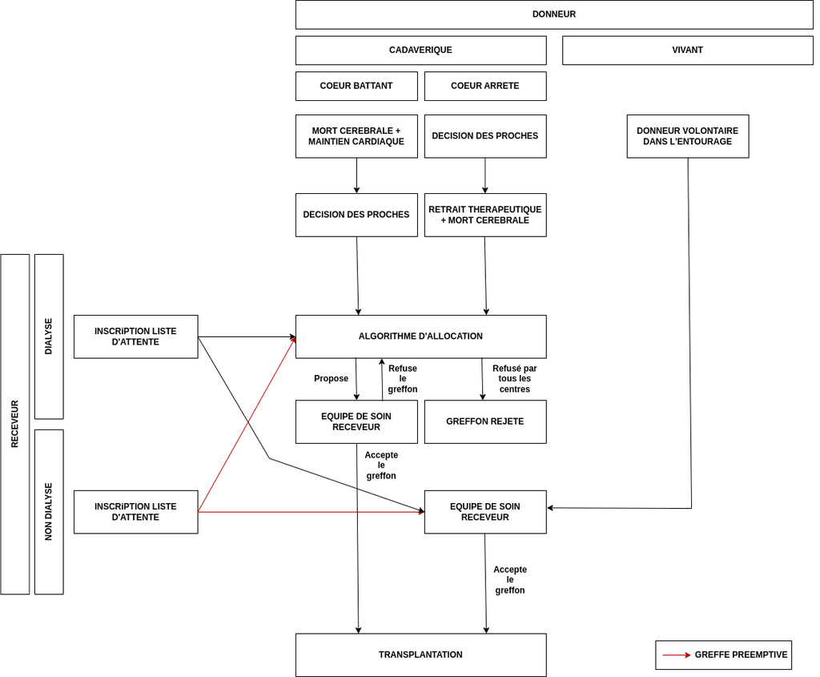

Système d’allocation des greffons en France

Lorsque l’algorithme propose un greffon à un centre de transplantation, il propose aux cliniciens une liste ordonnée de 5 patients du centre pouvant le recevoir. Les cliniciens sont alors libres de l’attribuer à un de ces 5 patients, à un autre patient du centre ou de le refuser. Ces choix se font en connaissance des caractéristiques du donneur et des receveurs potentiels, dont la marginalité du greffon décrite par le score ECD.

## Articles citant les travaux de SPHERE

### Querard et al. 2016

**Sharif 2022:** Insiste sur la nécessité de développer des outils d’aide à la prise de décision en transplantation rénale. Considère le sur-risque associé à un greffon ECD comme marginal par rapport à une attente prolongée sur liste de greffe.

**Larkins et al. 2021:** Suggère la possibilité de considérer les interactions entre les caractéristiques du donneur et du receveur, mais n’applique cette démarche que pour les âges. Constate une similitude apparente entre les résultats dans des pays avec des systèmes de santé plus proches.

**Mesnard et al. 2023:** Se base sur la méta-analyse pour justifier une revue systématique sur les résultats des greffes avec donneurs âgés (+70 ans). Conclut un important sur-risque de DGF, sans répercussion sur la survie à long terme, et suggère une plus grande considération de cette source de greffons.

**Echterdiek et al. 2019:** Se base sur la méta-analyse pour illuster le sur-risque associé à la réception d’un greffon ECD par rapport à un greffon SCD. Propose une étude comparative des outcomes des greffes avec greffons issus de donneurs entre 70 et 79 ans entre les décennies 1997-2006 et 2007-2016. Conclut que la survie à 5 ans des greffons de donneurs 70-79 s’est améliorée sur la deuxième décennie pour atteindre le niveau des greffons 60-69 sur la décennie précédente. Même résultat pour les greffons 60-69 par rapport aux greffons 50-59.

**Dahmen et al. 2019:** Propose une validation du KDPI sur cohorte européenne (Allemagne). Suggère la construction d’un KDPI ajusté pour la population européenne et le focus sur l’âge du donneur comme critère de décision principal. Suggère que le KDPI pourrait être marginalement supérieur à l’âge du donneur comme critère de marginalité, et pourrait présenter des avantages sur l’ECD. Ne propose pas d’évaluation des capacités pronostiques.

### Querard et al. 2018

**Santos et al. 2019:** Propose une étude de série de cas pour discuter de la faisabilité de l’extension des critères d’acceptation aux greffons classifiés KDIGO III AKI (severe acute kidney injury, échelon maximal d’une classification en 3 classes). Suggère une éventuelle utilisation de ces greffons en transplantation sous condition de haute créatininémie.

## Objectifs

En prenant en compte les remarques précédentes, l’objectif principal de ce projet doit être de construire un score de marginalité du donneur prédictif de la survie du greffon pour la population française en transplantation rénale. On devra attacher une attention particulière à l’évaluation de l’effet marginal d’une greffe sur le critère établi et à la prise en compte des covariables et des interactions entre les caractéristiques du donneur et du receveur.

Additionnellement, on propose de développer un outil de profilage permettant d’identifier, pour un greffon marginal donné, les profils de patient pouvant bénéficier au mieux d’une greffe de ce greffon au regard du bénéfice attendu avec un greffon non marginal.

# Plan d’analyse

Cette section résume les étapes du projet décrites par la fiche ABM. Les éléments en rouge correspondent au choix à faire par rapport aux éléments intégrés suite aux suggestions des experts et aux suggestions personnelles.

## Extraction des données

**Prise en main des données:**

- Vérification de cohérence élémentaire (données a priori déjà data managées) / vérification des critères d’inclusion
- Ajustement du libellé et passage en facteurs des catégories si besoin
- Réorganisation des colonnes pour faciliter la lecture par la suite
- Echantillon de validation interne aléatoire 2/3-1/3.

## Description des données

**Description de l’échantillon à baseline:**

- Tableau descriptif des données (effectifs, proportions, moyennes, ecarts-types, médianes) par échantillon.
- Nombres de données manquantes.
  - Exclusion des variables à forte proportion de données manquantes (+ de 15%) et quasi-séparées (Plus de 90% dans une modalité).
- Tableau descriptif des données par centre.

**Description du suivi:**

- Kaplan-Meier global et par centre dans chaque échantillon.
- Kaplan-Meier tronqué par centre.
- Statistiques descriptives de la survie dans chaque échantillon.

## Screening univarié

- Modèles de Cox univariés retenant les variables à $p \le 0.2$
- Vérification graphique des hypothèses de log-linéarité sur les 95 percentiles centraux des résidus de martingale et adaptation si besoin.
- Vérification graphique de l’hypothèse de proportionnalité des risques via les résidus de Schoenfeld (toutes les variables), et par $log-log$ (variables catégorielles).

## Sélection des variables du donneur

**Sélection multivariée:**

- Injection des variables du donneur retenues en univarié dans un modèle multivarié.
- Sélection pas-à-pas descendante à $p \le 0.05$.

## Sélection des variables de la greffe

**Sélection multivariée:**

- Injection des variables de la greffe retenues en univarié dans un modèle multivarié avec les variables du donneur retenues à l’étape précédente.
- Sélection pas-à-pas descendante à $p \le 0.05$ en forcant les variables du donneur.

## Sélection des variables du receveur

**Sélection multivariée:**

- Injection des variables du receveur retenues en univarié dans un modèle multivarié avec les variables du donneur et de la greffe retenues à l’étape précédente.
- Sélection pas-à-pas descendante à $p \le 0.05$ en forcant les variables du donneur et de la greffe.

## Etude des interactions

**Screening univarié:**

- Croisement des variables du donneur avec celles du receveur et de la greffe dans des modèles de régression linéaire et tests du $\chi2$ univariés et mise de côté des paires avec $p \le 0.2$.

**Sélection multivariée:**

- Test de la significativité des interactions entre les paires mises de côté de variables présentes dans le modèle en les injectant une à une dans le modèle ($p \le 0.2$).
- Sélection descendante en forcant les effets simples, critère d’arrêt $p \le 0.05$.
- Test de la significativité des interactions entre les paires mises de côté comprenant une variable du modèle et une variable hors du modèle en les injectant une à une dans le modèle ($p \le 0.2$).
- Sélection descendante en forcant les effets simples et les interactions internes, critère d’arrêt $p \le 0.05$.

## Amélioration du modèle

**Enrichissement du modèle:**

- Test d’ajout des variables absentes du modèle dans le modèle obtenu à l’issue des étapes précédentes, retenant les variables avec $p \le 0.2$.
- Sélection descendante en forcant tout sauf ces nouvelles variables dans le modèle.

**Remise en cause des effets fixes:**

- Sélection descendante en forcant les interactions pour éliminer les variables ajustées par des effets ajoutés au modèle après leur sélection.
- Vérification de l’absence d’effet confondant des variables éliminées sur les variables du donneur (variation de coefficient de + de 10% ou augmentation de l’AIC après suppression sur cas complets). Conservation de la variable si c’est le cas.

**Enrichissement des interactions:**

- Nouveau test des interactions entre les variables présentes dans le modèle.
- Sélection descendante en forcant tout sauf les interactions nouvellement ajoutées.

## Gestion de l’effet période/ effet centre

**Effet centre:**

- Evaluation de la significativité de l’effet centre dans un modèle de fragilité avec un effet aléatoire (spécifié loi gamma) et comparaison de l’AIC avec le modèle sans effet centre.

**Effet période:**

- Test de la significativité du régresseur linéaire d’un indicateur binaire avant après pour les dates entre 2007 et 2012.
- Test avec modèle de fragilité si proportionnalité des risques non respectée.

**Amélioration du modèle:**

- Répétition des étapes d’amélioration du modèle sur le modèle comprenant les éventuels effets période et centre.

## Calcul du score

- A DETERMINER

## Validation du score

**Evaluation de la qualité du modèle:** Validation rapide des bonnes propriétés et hypothèses a posteriori du modèle.

- Test a posteriori de la proportionnalité des risques.

**Description de l’échantillon en fonction du score:**

- Attention particulière aux outcomes secondaires et aux potentielles différences entre les groupes formés par le score.
- Scatterplot/ boxplot du score en fonction de ses différentes composantes pour illustrer l’importance de chaque facteur et les corrélations score/variables.

**Evaluation des capacités pronostiques:** Etude des performances pronostiques avec prise en compte des covariables, évaluation de la calibration et du pouvoir discriminant.

- Calibration
  - Calibration plot (Intercept optimal de 0 et pente optimale de 1)
  - Calibration slope et intercept (+shrinkage si besoin)
- Discrimination
  - Courbe ROC temps-dépendante **sans** ajustement sur les covariables entre 1 an et X ans.
  - AUC, VPP/VPN, Se/Sp
  - Calibration slope (discrimination sur la probabilité de survie)
  - HDS (Hazard Discrimination Summary)
  - (Courbe ROC temps-dépendante ajustée)
  - Courbe ROC selon les strates de receveur: AUC espérée minimale chez les receveurs à faible risque et maximale chez les receveurs à risque.
- Performance globale
  - Brier score
- Validation externe si possible.

**A explorer/ si temps pour le faire:**

- Probabilités de survie avec stratification sur le score / décision sur le seuil (contrefactuel via SP, avec vérification des hypothèses de l’inférence causale) [3]
- **Analyse de sensibilité:** Si problème de données manquantes relevé, évaluation exploratoire de leur impact sur les résultats.
  - Imputation multiple (random forest MICE) pour les données MAR (packages CALIBERrfimpute, missForest, randomForest) [6]
  - Imputation par analyse factorielle (ACP, AFC)
  - Régression LASSO pour la sélection multivariée via le package `glmnet` (inclut la réduction du modèle et le shrinkage).

## Construction du calculateur en ligne

- Application en ligne permettant de calculer le score en fonction des caractéristiques du greffon et du receveur.
- Estimation de la probabilité d’échec de greffe.

## Autres considérations

- Eventuellement, ouverture vers une évaluation d’une potentielle implémentation du score dans l’attribution. Attention particulière à la différence de survie espérée entre un receveur acceptant le greffon et ce même receveur refusant le greffon.
- Si accès à des données internationales pour validation externe, reporting détaillé pour chaque pays dans lequel le score pourra être testé.

## Variables

#### Variables du donneur

Petite revue de la littérature pour s’imprégner du contexte clinique.

**Âge, sexe**

**Type de décès (TypeD3cl):** donneur avec coeur battant ou coeur arrêté * Extension plus récente aux donneurs après la mort circulatoire, avec des résultats (registre britannique, étude andalouse) présentant des outcomes similaires à ceux observés chez les receveurs de greffons issus de donneurs en mort cérébrale, en particulier à plus long terme.

**Taille, poids, IMC:** Choix à faire parmi les 3 variables, redondantes. Le choix de l’IMC semble plus intéressant car plus parcimonieux sans perte importante d’information utile dans ce contexte clinique.

**Cause de décès:** Décès du donneur de cause vasculaire ou non vasculaire. * Pas d’a priori épidémiologique particulier sur la relation entre la survie et la cause de décès ainsi dichotomisée. A confirmer avec clinicien.

**Antécédants:**

- **HTA**
- **Diabète** Pourrait être associé à un effet délétère sur la survie du greffon.
- **Dyslipidémie** Cholestérol ou triglycérides élevés.
- **Arrêt cardiaque**

**Biologie:**

- **Protéinurie** Bas niveaux de protéinurie étaient considérés problématiques, mais plusieurs études de cohortes (principalement en Suisse et au Royaume-Uni) ont échoué à mettre en évidence un effet délétère sur le risque d’échec de greffe.
- **Hématurie** Présence de globules rouges dans les urines, souvent causée par une infection urinaire ou des lésions rénales.
- **Créatininémie** Choix à faire entre continu et en 2 classes.
- **Urée** Produit de la dégradation des protéines, marqueur de la fonction rénale.
- **Dernière diurèse** Mesure de la quantité d’urines éliminées au cours de la dernière heure. Marqueur de la fonction rénale du greffon.

#### Autres variables

**Sérologie:**

- **HIV** Marque le VIH
- **HB/ anti-HB** Antigène de surface du virus de l’hépatite B et anticorps associés.
- **HCV** Virus de l’hépatite C
- **EBV** Virus d’Esptein-Barr

**Antécédents receveur**

- **Diabète, Dyslipidémie, HTA, cardio-vasculaire, uro-néphrologique, tabac, grossesse**
- **Néoplasie** Tumeur cancéreuse ou non cancéreuse.

**Immunologie**

- **Incompatibilités HLA et ABO** entre le donneur et le receveur
- **Traitement d’induction** Traitement pré-greffe visant à diminuer la réponse immune du receveur.
- **Inhibiteurs de calcineurine, mTOR et antiprolifératifs** Immunosuppresseurs utilisés post-greffe comme traitements d’entretien.
- **Immunisation anti-HLA** Détection chez le receveur d’anticorps dirigés contre les antigènes HLA du donneur.
- **DSA** Anticorps spécifiques du donneur.

# Ressources

## Rapport

## Slides

## Code

## Autres